# Presentación y Análisis de Resultados

Sebastian Zabala

27 de julio de 2026

# 1 Resultados del Estudio de Simulación

## 1.1 Procedimiento de generación de los procesos AR(1).

Para determinar la calidad del proceso de generación propuesto en el esquema de simulación del capítulo 3, se emplean los tres niveles de dependencia ($\phi$) de los procesos estocásticos AR(1) simulados en el capítulo 2 para generar muestras de una densidad normal estándar truncada en [-2,2] con $n=500$ utilizando una semilla fija (`set.seed(123)`) para garantizar la reproducibilidad.

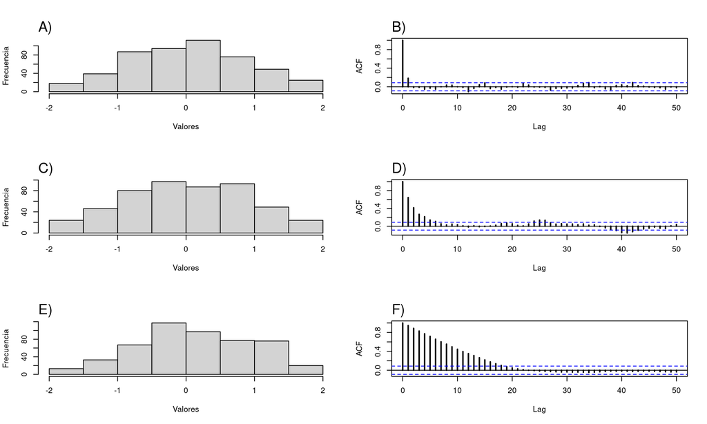

Figure 1.1: Histogramas y funciones de autocorrelación (ACF) empíricas de los procesos X generados bajo distintos niveles de dependencia (ϕ=0.25,0.65,0.95) de un modelo AR(1) con semilla fija (set.seed(123).

```r
# Configuración de la cuadrícula: 3 filas, 2 columnas
par(mfrow = c(3, 2))
set.seed(123)

# ============================================
# Caso φ = 0.25 (Fila 1)
# ============================================

# Panel A: Histograma
X1 <- gnormtrunc_dep(500, 0.25, -2, 2, 0, 1)
hist(X1, main = "", xlab = "Valores", ylab = "Frecuencia",
     col = "lightgray", border = "black")
mtext("A)", side = 3, adj = 0, line = 0.5, font = 1.5, cex = 1.2)

# Panel B: ACF
acf(X1, lag.max = 50, main = "", lwd = 2)
mtext("B)", side = 3, adj = 0, line = 0.5, font = 1.5, cex = 1.2)

# ============================================
# Caso φ = 0.65 (Fila 2)
# ============================================

# Panel C: Histograma
X2 <- gnormtrunc_dep(500, 0.65, -2, 2, 0, 1)
hist(X2, main = "", xlab = "Valores", ylab = "Frecuencia",
     col = "lightgray", border = "black")
mtext("C)", side = 3, adj = 0, line = 0.5, font = 1.5, cex = 1.2)

# Panel D: ACF
acf(X2, lag.max = 50, main = "", lwd = 2)
mtext("D)", side = 3, adj = 0, line = 0.5, font = 1.5, cex = 1.2)

# ============================================
# Caso φ = 0.95 (Fila 3)
# ============================================

# Panel E: Histograma
X3 <- gnormtrunc_dep(500, 0.95, -2, 2, 0, 1)
hist(X3, main = "", xlab = "Valores", ylab = "Frecuencia",
     col = "lightgray", border = "black")
mtext("E)", side = 3, adj = 0, line = 0.5, font = 1.5, cex = 1.2)

# Panel F: ACF
acf(X3, lag.max = 50, main = "", lwd = 2)
mtext("F)", side = 3, adj = 0, line = 0.5, font = 1.5, cex = 1.2)
```

```r
# Restaurar configuración gráfica
par(mfrow = c(1, 1))
```

La figura 1.1 muestra los histogramas de las series simuladas ($n = 500$) con distribución normal truncada en $[-2, 2]$ y los gráficos de sus funciones de autocorrelación (ACF); las líneas azules punteadas indican los límites de significancia aproximados ($\pm 2/\sqrt{n}$). En esta se evidencia que los procesos generados tienen una forma acampanada como la distribucion normal y que según sea el nivel de dependencia ($\phi$) el decaimiento de su función de autocorrelación es mayor o menor.

Dado que estos hallazgos se corresponden con la teoría estudiada queda garantizada la calidad de las series generadas por el esquema de simulación. Por esto, se procede a simular series débilmente dependientes con distintas densidades marginales $f(x)$.

## 1.2 Estudio de caso: Densidad Normal Estándar Truncada (Control)

Casos de estudio de densidad normal estándar truncada en [-2,2]: Comportamiento en fronteras bajo independencia ($\phi = 0$)

### 1.2.1 Caso A: Muestra pequeña ($n=200$)

```r
set.seed(1234)
resultados_X11 <- analizar_y_graficar_trunc(n = 200,
                                            phi = 0,
                                            a = -2,
                                            b = 2,
                                            m = 0,
                                            de = 1,
                                            lim_inf = -3,
                                            lim_sup = 3,
                                            titulo_base = "X11")
```

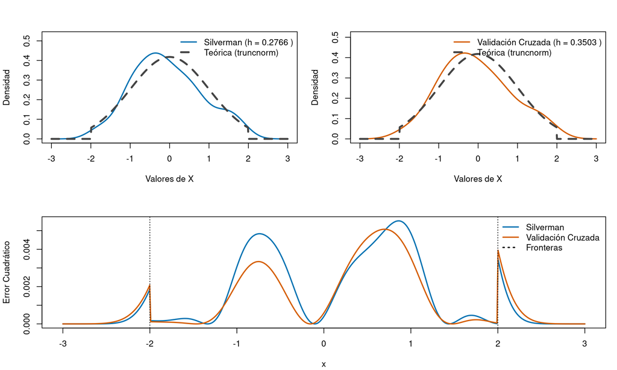

Figure 1.2: Estimación de densidad normal estandar truncada en [-2,2] para una malla de 512 puntos en [-3,3] (phi=0, n=200)

Se observa que los métodos clásicos seleccionan anchos de ventana que permiten al estimador por núcleo aproximarse adecuadamente a la densidad teórica. Por otro lado, se aprecia que el método de validación cruzada presenta errores cuadráticos más pequeños que el método de Silverman en la mayoría de los puntos de la malla de estimación.

```r
# par(mfrow=c(1,2))
# graficar_densidades_trunc(dens_nrd0_X11, "nrd0", a = -2, b = 2, m = 0, de = 1, titulo = "X11 (n=200)")
# graficar_densidades_trunc(dens_ucv_X11, "ucv",  a = -2, b = 2, m = 0, de = 1, titulo = "X11 (n=200)")
# par(mfrow=c(1,1))
```

```r
# diagnostico_error_local(X11, dens_nrd0_X11, dens_ucv_X11, a = -2, b = 2, m = 0, de = 1, lim_inf = -3, lim_sup = 3, titulo = "X11 (n=200, phi=0)")
```

### 1.2.2 Caso B: Comportamiento asintótico ($n=2000$)

```r
set.seed(4321)
resultados_X12 <- analizar_y_graficar_trunc(n = 2000,
                                            phi = 0,
                                            a = -2,
                                            b = 2,
                                            m = 0,
                                            de = 1,
                                            lim_inf = -3,
                                            lim_sup = 3,
                                            titulo_base = "X12")
```

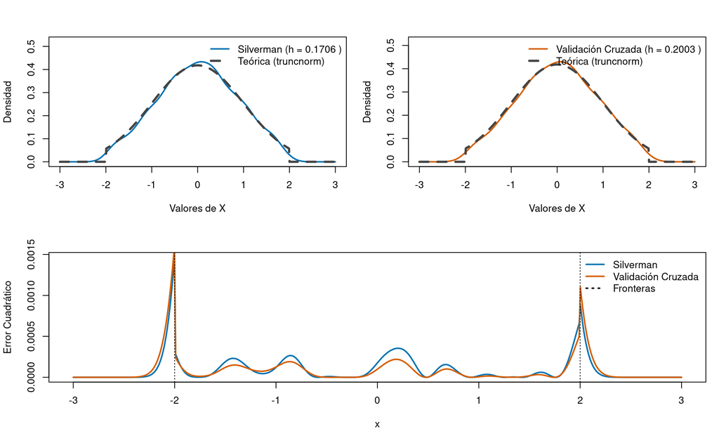

Figure 1.3: Estimación de densidad normal estandar truncada en [-2,2] para una malla de 512 puntos en [-3,3] (phi=0, n=2000)

En la Figura 1.3 se evidencia que los métodos clásicos seleccionan un ancho de ventana que permite al estimador por núcleo aproximarse casi perfectamente a la densidad teórica. Esto se debe a su carácter asintótico: a medida que $n$ crece, la precisión aumenta, especialmente cuando la densidad objetivo es suave. Aunque Silverman sigue mostrando errores cuadráticos ligeramente superiores, las diferencias se reducen considerablemente. Esto evidencia, al menos para este caso, que el incremento muestral conduce a estimaciones más precisas, conforme a la teoría.

## 1.3 Casos de Estudio de densidad normal truncada en [-2,2]: Comportamiento en Fronteras bajo Dependencia Fuerte ($\phi = 0.9$)

### 1.3.1 Caso C: Muestra pequeña ($n=200$)

```r
set.seed(9876)
resultados_X13 <- analizar_y_graficar_trunc(n = 200,
                                            phi = 0.9,
                                            a = -2,
                                            b = 2,
                                            m = 0,
                                            de = 1,
                                            lim_inf = -3,
                                            lim_sup = 3,
                                            titulo_base = "X13")
```

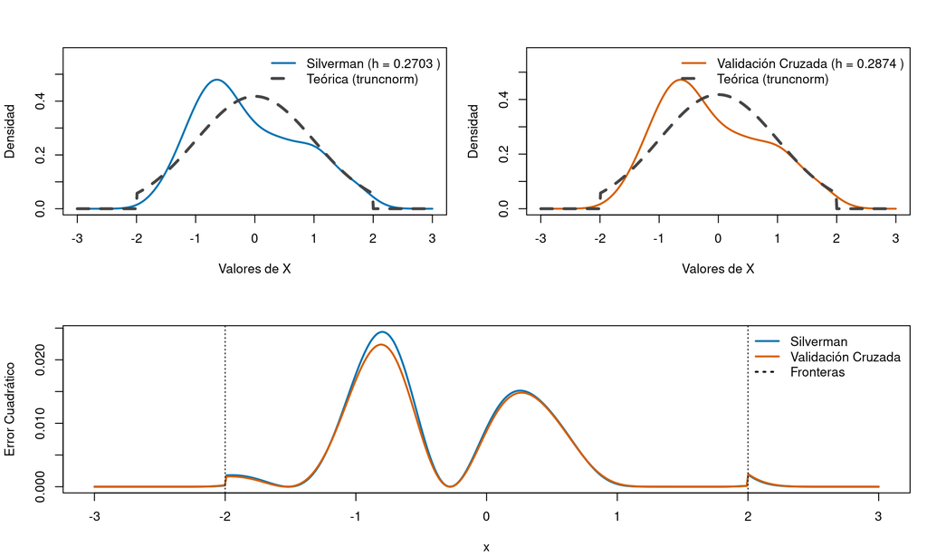

En este caso, los métodos de selección clásicos no estiman adecuadamente la densidad, resultando en una estimación con asimetría positiva para ambos métodos. Esto evidencia, al menos para esta muestra, que la dependencia débil impacta negativamente en la eficiencia de los selectores clásicos. Los datos altamente correlacionados tienden a formar aglomeraciones (clústeres), dejando zonas de la distribución con escasa información. Por ello, se observan mayores errores cuadráticos que en los casos anteriores donde ambos métodos producen resultados similares.

### 1.3.2 Caso D: Comportamiento asintótico ($n=2000$)

```r
set.seed(5678)
resultados_X14 <- analizar_y_graficar_trunc(n = 2000,
                                            phi = 0.9,
                                            a = -2,
                                            b = 2,
                                            m = 0,
                                            de = 1,
                                            lim_inf = -3,
                                            lim_sup = 3,
                                            titulo_base = "X14")
```

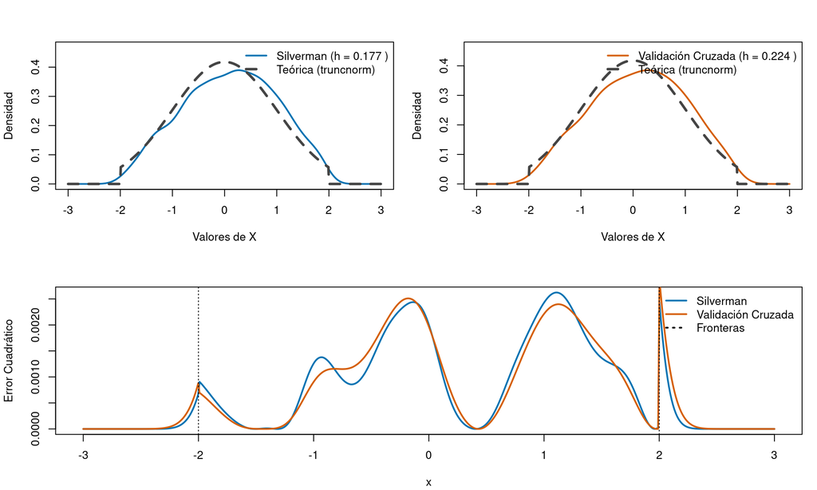

Ambos métodos producen estimaciones cercanas a la densidad teórica, con errores cuadráticos pequeños que son ligeramente mayores a los que se obtuvieron con el mismo $n$ y $\phi=0$. En ciertas regiones, el método de Silverman presenta errores más grandes que validación cruzada, y viceversa. Esto sugiere que, incluso bajo dependencia débil, el incremento del tamaño muestral permite obtener estimaciones aceptables, al menos para esta realización particular.

## 1.4 Casos de estudio: Comportamiento de los métodos con $p=1000$ réplicas

El análisis basado en una única muestra no proporciona evidencia suficiente sobre el desempeño promedio del estimador por núcleo bajo diferentes métodos de selección del ancho de ventana, niveles de dependencia y tamaños muestrales, ya que los resultados pueden variar de una muestra a otra y entre escenarios. Por ello, a continuación se presentan los resultados de un estudio de simulación considerando una mayor cantidad de réplicas ($p>1$) para cada una de las combinaciones de $n$ y $\phi$ contemplada. Las estimaciones se realizaron sobre una malla de 512 puntos igualmente espaciados en el intervalo [-3,3] para cada una de las densidades analizadas. La calidad de las estimaciones se evalúa mediante el error cuadrático integrado (ISE), su promedio (MISE) y el error cuadrático medio (MSE).

### 1.4.1 Comportamiento con la densidad normal estándar truncada en [-2,2].

A continuación se muestra una tabla con los errores cuadráticos medios integrados (MISE) obtenidos para $p=1000$ réplicas, para cada combinación de $n$ y $\phi$, evaluados sobre una malla de $n=512$ puntos igualmente espaciados en el intervalo [-3,3] para una densidad normal estándar truncada en [-2,2]:

```r
# ==============================================================================
# 1. PARÁMETROS DEL ESTUDIO DE SIMULACIÓN
# ==============================================================================
n_vals <- c(200, 500, 1000, 2000)
phi_vals <- c(0, 0.5, 0.9)
M <- 1000

# Parámetros fijos de la distribución truncada y la malla de estimación
a_t <- -2
b_t <- 2
m_t <- 0
de_t <- 1

# Parámetros estrictos de la malla (Garantizan comparabilidad)
lim_inf <- -3
lim_sup <- 3
n_grid <- 512

# Pre-asignar un data.frame vacío para guardar el resumen final
resultados_mise <- data.frame(
  n = integer(),
  phi = numeric(),
  metodo = character(),
  mise = numeric()
)


# Pre-asignar un data.frame vacío para TODOS los errores (serán 24,000 filas)
resultados_completos <- data.frame(
  n = factor(),
  phi = factor(),
  metodo = character(),
  ise = numeric()
)

# ==============================================================================
# 2. CONFIGURACIÓN DEL CLÚSTER PARALELO
# ==============================================================================
# Detectar núcleos disponibles dejando uno libre para la estabilidad del sistema
num_cores <- max(1, parallel::detectCores() - 1)
cl <- makeCluster(num_cores)
registerDoParallel(cl)

# ==============================================================================
# 3. BUCLE PRINCIPAL (MONTE CARLO PARALELIZADO)
# ==============================================================================
# Fijamos una sola semilla global inicial para todo el experimento
set.seed(999)

for (phi in phi_vals) {
  for (n in n_vals) {

    # foreach divide las M iteraciones entre los núcleos de forma simultánea
    errores_mc <- foreach(m = 1:M, .combine = 'rbind', .packages = c("truncnorm", "stats")) %dopar% {

      # 1. Generar la muestra estocástica
      X <- gnormtrunc_dep(nsim = n, phi = phi, a = a_t, b = b_t, m = m_t, de = de_t)

      # 2. Estimaciones clásicas forzando la malla estricta [-3, 3] con 512 puntos
      d_nrd0 <- density(X, bw = "nrd0", from = lim_inf, to = lim_sup, n = n_grid)

      # tryCatch previene que validación cruzada aborte todo el script si no converge
      d_ucv <- tryCatch({
        suppressWarnings(density(X, bw = "ucv", from = lim_inf, to = lim_sup, n = n_grid))
      }, error = function(e) {
        # Si ucv falla por ruido excesivo en la muestra, retorna nrd0 para esa réplica
        return(d_nrd0)
      })

      # 3. Extraer la malla exacta (idéntica en cada iteración) y evaluar la densidad teórica
      x_grid <- d_nrd0$x
      y_teo <- dtruncnorm(x_grid, a = a_t, b = b_t, mean = m_t, sd = de_t)

      # 4. Calcular el Error Cuadrático Integrado (ise)
      # Se usa la aproximación geométrica (suma de Riemann) sobre la malla
      delta_x <- x_grid[2] - x_grid[1]
      ise_nrd0 <- sum((d_nrd0$y - y_teo)^2) * delta_x
      ise_ucv  <- sum((d_ucv$y - y_teo)^2) * delta_x

      # Retornar los errores de esta iteración específica
      c(ise_nrd0, ise_ucv)
    }

    # 5. Calcular el MISE promediando los ISE de las M réplicas
    mise_nrd0 <- mean(errores_mc[, 1])
    mise_ucv  <- mean(errores_mc[, 2])

    # 6. Guardar los resultados del MISE
    resultados_mise <- rbind(resultados_mise,
                             data.frame(n = n, phi = phi, metodo = "Silverman (nrd0)", mise = mise_nrd0),
                             data.frame(n = n, phi = phi, metodo = "UCV", mise = mise_ucv))

    # -------------------------------------------------------------------------
    # 7. NUEVO: Guardar TODOS los ISE individuales en lugar de solo el promedio
    # Esto va ADENTRO del bucle de "n"
    # -------------------------------------------------------------------------

    # Creamos un data.frame temporal para Silverman
    df_nrd0 <- data.frame(
      n = as.factor(n),
      phi = paste("Dependencia (phi) =", phi),
      metodo = "Silverman",
      ise = errores_mc[, 1]
    )

    # Creamos un data.frame temporal para UCV
    df_ucv <- data.frame(
      n = as.factor(n),
      phi = paste("Dependencia (phi) =", phi),
      metodo = "UCV",
      ise = errores_mc[, 2]
    )

    # Unimos al data.frame maestro
    resultados_completos <- rbind(resultados_completos, df_nrd0, df_ucv)

  } # Cierra el bucle de "n"
} # Cierra el bucle de "phi"

# Detener el clúster paralelo para liberar recursos del procesador
stopCluster(cl)

# ==============================================================================
# 4. PRESENTACIÓN DE RESULTADOS
# ==============================================================================
# Renombrar columnas para la salida
colnames(resultados_mise) <- c("Tamaño Muestral (n)", "Dependencia (phi)", "Selector Empírico", "MISE")

titulo_tabla <- "<i>Error Cuadrático Medio Integrado (MISE) para selectores clásicos sobre una malla fija de 512 puntos, basado en 1000 iteraciones de Monte Carlo.</i>"

generar_tabla_apa(resultados_mise, titulo_tabla)
```

Table 1.1: *Error Cuadrático Medio Integrado (MISE) para selectores clásicos sobre una malla fija de 512 puntos, basado en 1000 iteraciones de Monte Carlo.*

| Tamaño Muestral (n) | Dependencia (phi) | Selector Empírico | MISE |
| --- | --- | --- | --- |
| 200 | 0.0 | Silverman (nrd0) | 0.004504 |
| 200 | 0.0 | UCV | 0.005497 |
| 500 | 0.0 | Silverman (nrd0) | 0.002374 |
| 500 | 0.0 | UCV | 0.002809 |
| 1000 | 0.0 | Silverman (nrd0) | 0.001518 |
| 1000 | 0.0 | UCV | 0.001716 |
| 2000 | 0.0 | Silverman (nrd0) | 0.000969 |
| 2000 | 0.0 | UCV | 0.001111 |
| 200 | 0.5 | Silverman (nrd0) | 0.006662 |
| 200 | 0.5 | UCV | 0.007426 |
| 500 | 0.5 | Silverman (nrd0) | 0.003297 |
| 500 | 0.5 | UCV | 0.003762 |
| 1000 | 0.5 | Silverman (nrd0) | 0.001996 |
| 1000 | 0.5 | UCV | 0.002224 |
| 2000 | 0.5 | Silverman (nrd0) | 0.001211 |
| 2000 | 0.5 | UCV | 0.001354 |
| 200 | 0.9 | Silverman (nrd0) | 0.028334 |
| 200 | 0.9 | UCV | 0.031067 |
| 500 | 0.9 | Silverman (nrd0) | 0.012348 |
| 500 | 0.9 | UCV | 0.013124 |
| 1000 | 0.9 | Silverman (nrd0) | 0.007245 |
| 1000 | 0.9 | UCV | 0.007499 |
| 2000 | 0.9 | Silverman (nrd0) | 0.003699 |
| 2000 | 0.9 | UCV | 0.003860 |

Se observa que en promedio, ambos métodos producen resultados similares, sin diferencias notables entre sus respectivos $MISE(x)$ para cada combinación de $n$ y $\phi$. Sin embargo, para $n=200$ y $\phi=0.9$, los errores son aproximadamente seis veces superiores a los obtenidos con el mismo tamaño muestral pero bajo independencia ($\phi=0$). Esto indica que, con muestras reducidas, los selectores clásicos no logran estimar adecuadamente la densidad cuando la dependencia es débil. Este comportamiento se ilustra en la siguiente figura:

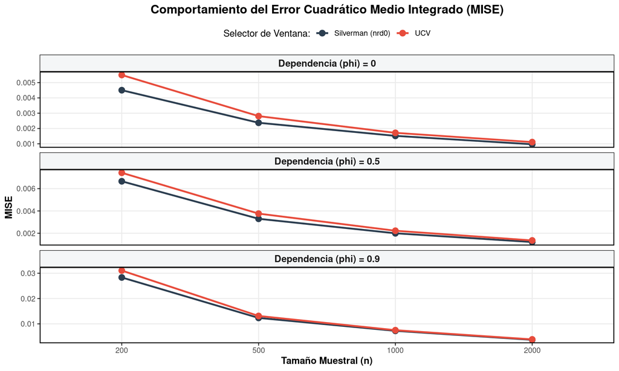

Figure 1.6: Evolución del Error Cuadrático Medio Integrado (MISE) en función del tamaño muestral bajo distintos niveles de dependencia AR(1).

```r
# Gráfico de Líneas y Puntos para el MISE usando los nombres de columnas actualizados
grafico_mise <- ggplot(resultados_mise, aes(x = factor(`Tamaño Muestral (n)`),
                                            y = MISE,
                                            color = `Selector Empírico`,
                                            group = `Selector Empírico`)) +
  # Agregamos las líneas y los puntos
  geom_line(linewidth = 1) +
  geom_point(size = 3) +
  # Separamos por nivel de dependencia (phi) usando el nuevo nombre de la columna
  facet_wrap(~ paste("Dependencia (phi) =", `Dependencia (phi)`), scales = "free_y", ncol = 1) +
  # Colores sobrios y académicos
  scale_color_manual(values = c("Silverman (nrd0)" = "#2c3e50", "UCV" = "#e74c3c")) +
  # Etiquetas formales
  labs(
    title = "Comportamiento del Error Cuadrático Medio Integrado (MISE)",
    x = "Tamaño Muestral (n)",
    y = "MISE",
    color = "Selector de Ventana:"
  ) +
  # Tema estricto para tesis
  theme_bw() +
  theme(
    legend.position = "top",
    plot.title = element_text(face = "bold", hjust = 0.5, size = 14),
    axis.title = element_text(face = "bold"),
    strip.text = element_text(size = 11, face = "bold"),
    strip.background = element_rect(fill = "#f4f6f7", color = "black"),
    panel.grid.minor = element_blank(), # Elimina líneas de cuadrícula innecesarias
    panel.border = element_rect(color = "black", linewidth = 1)
  )

print(grafico_mise)
```

En la figura anterior se observa cómo la validación cruzada produce, en promedio, errores consistentemente mayores que el método de Silverman; esto puede deberse a que la ventana estimada con Silverman asume normalidad y regularidad de orden 2 ($\beta=2$), condición que coincide con la densidad teórica en este caso. Por otro lado, a medida en que $n$ aumenta en promedio los errores de ambos métodos tienden a cero, lo que concuerda con la teoría estudiada.

Para complementar lo anterior, se presenta un diagrama de cajas y bigotes para los errores cuadráticos integrados ($ISE$).

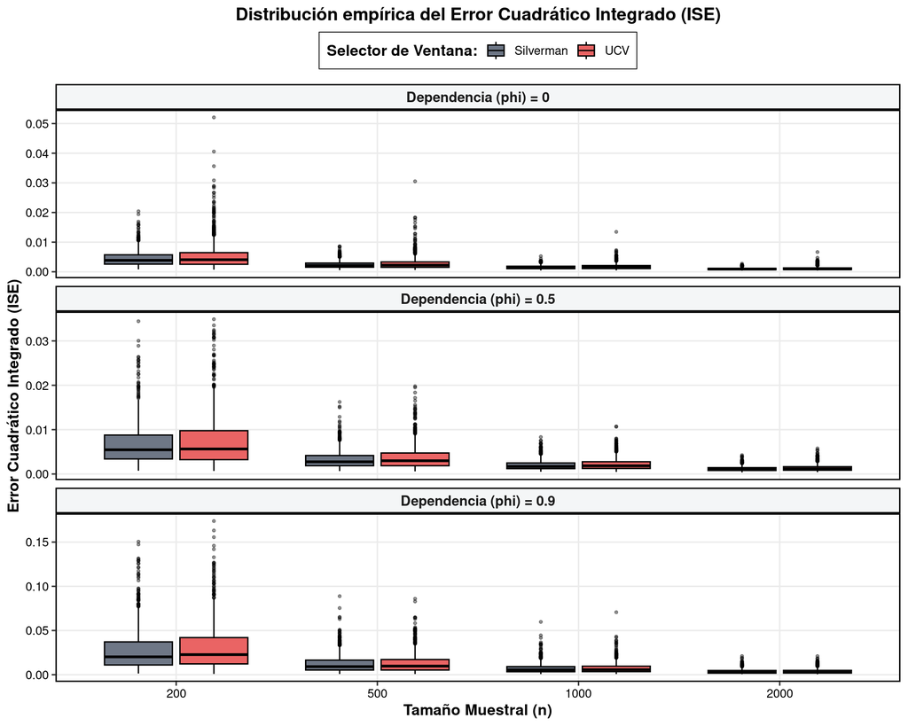

Figure 1.7: Distribución empírica del Error Cuadrático Integrado (ISE).

```r
library(ggplot2)

# Gráfico de Cajas Comparativo Optimizado para Tesis
grafico_cajas <- ggplot(resultados_completos, aes(x = n, y = ise, fill = metodo)) +
  # Ajuste de las líneas de la caja y transparencia de outliers para no saturar la tinta
  geom_boxplot(alpha = 0.8, outlier.size = 0.8, outlier.alpha = 0.4,
               color = "black", linewidth = 0.5) +
  # NUEVO: Agregar la media (MISE) como un rombo blanco para contrastar con la mediana
  # stat_summary(fun = mean, geom = "point", shape = 23, size = 2,
  #              fill = "white", color = "black",
  #              position = position_dodge(width = 0.75)) +
  # Separar paneles permitiendo que el eje Y escale independientemente
  facet_wrap(~ phi, scales = "free_y", ncol = 1) +
  # Tonos sobrios, elegantes y aptos para impresión (color ciego amigable)
  scale_fill_manual(values = c("Silverman" = "#4A5568", "UCV" = "#E53E3E")) +
  # Etiquetas formales
  labs(
    title = "Distribución empírica del Error Cuadrático Integrado (ISE)",
    # subtitle = "Variabilidad estocástica y sesgo bajo dependencia AR(1) (El rombo central indica el MISE)",
    x = "Tamaño Muestral (n)",
    y = "Error Cuadrático Integrado (ISE)",
    fill = "Selector de Ventana:"
  ) +
  # Usar theme_bw en lugar de minimal asegura recuadros negros delimitadores (ideal para tesis)
  theme_bw(base_size = 12) +
  theme(
    # Leyenda enmarcada y bien posicionada
    legend.position = "top",
    legend.title = element_text(face = "bold"),
    legend.background = element_rect(color = "black", linewidth = 0.3),
    # Títulos centrados
    plot.title = element_text(face = "bold", hjust = 0.5, size = 14),
    plot.subtitle = element_text(hjust = 0.5, size = 11, color = "gray30"),
    # Ejes con fuerte contraste
    axis.title = element_text(face = "bold"),
    axis.text = element_text(color = "black"),
    # Estilo de las cabeceras de cada panel (strip)
    strip.text = element_text(size = 11, face = "bold"),
    strip.background = element_rect(fill = "#f4f6f7", color = "black", linewidth = 1),
    # Bordes estrictos y limpieza de cuadrícula secundaria
    panel.border = element_rect(color = "black", linewidth = 1),
    panel.grid.minor = element_blank()
  )

print(grafico_cajas)
```

```r
resultados_Y21 <- analizar_y_graficar_mw(n = 200,
                                         phi = 0,
                                         mw_obj = mw_list[[2]],
                                         lim_inf = -5,
                                         lim_sup = 5,
                                         lineas_diag = c(-3, 3),
                                         titulo_base = "Y21")
```

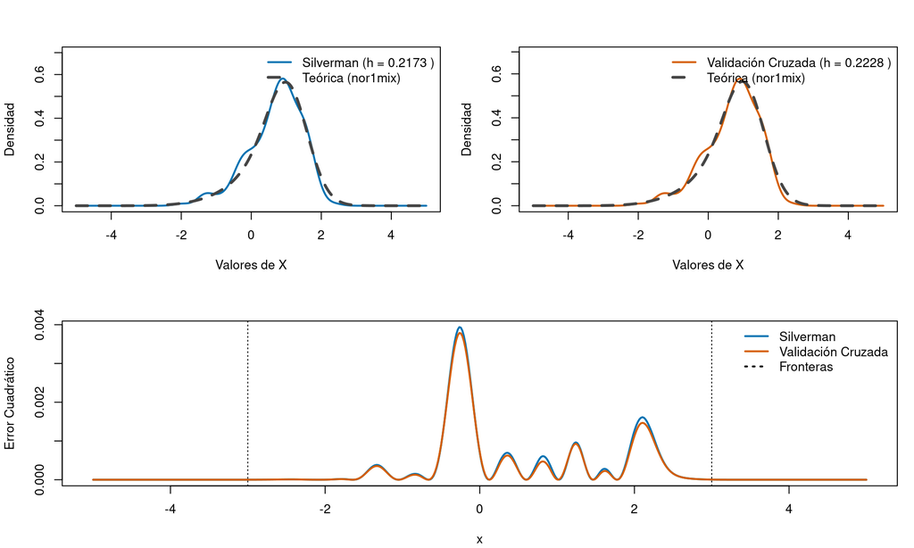

```r
resultados_Y22 <- analizar_y_graficar_mw(n = 2000,
                                         phi = 0,
                                         mw_obj = mw_list[[2]],
                                         lim_inf = -5,
                                         lim_sup = 5,
                                         lineas_diag = c(-3, 3),
                                         titulo_base = "Y22")
```

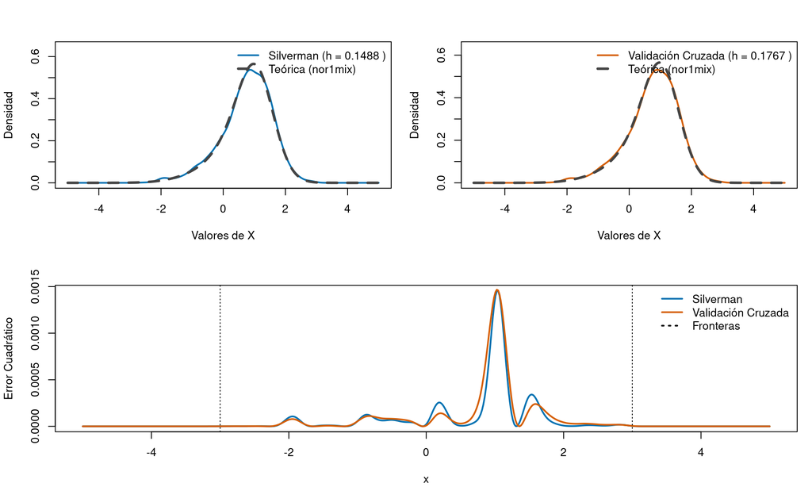

```r
resultados_Y23 <- analizar_y_graficar_mw(n = 200,
                                         phi = 0.9,
                                         mw_obj = mw_list[[2]],
                                         lim_inf = -5,
                                         lim_sup = 5,
                                         lineas_diag = c(-3, 3),
                                         titulo_base = "Y23")
```

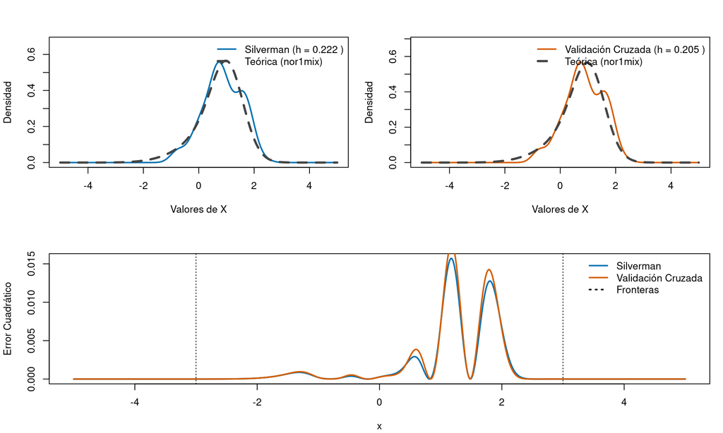

```r
resultados_Y24 <- analizar_y_graficar_mw(n = 2000,
                                         phi = 0.9,
                                         mw_obj = mw_list[[2]],
                                         lim_inf = -5,
                                         lim_sup = 5,
                                         lineas_diag = c(-3, 3),
                                         titulo_base = "Y24")
```

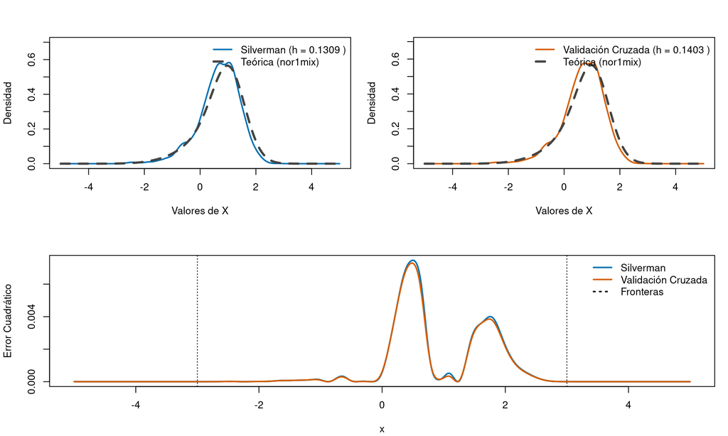

```r
resultados_Y31 <- analizar_y_graficar_mw(n = 200,
                                         phi = 0,
                                         mw_obj = mw_list[[3]],
                                         lim_inf = -5,
                                         lim_sup = 5,
                                         lineas_diag = c(-3, 3),
                                         titulo_base = "Y31")
```

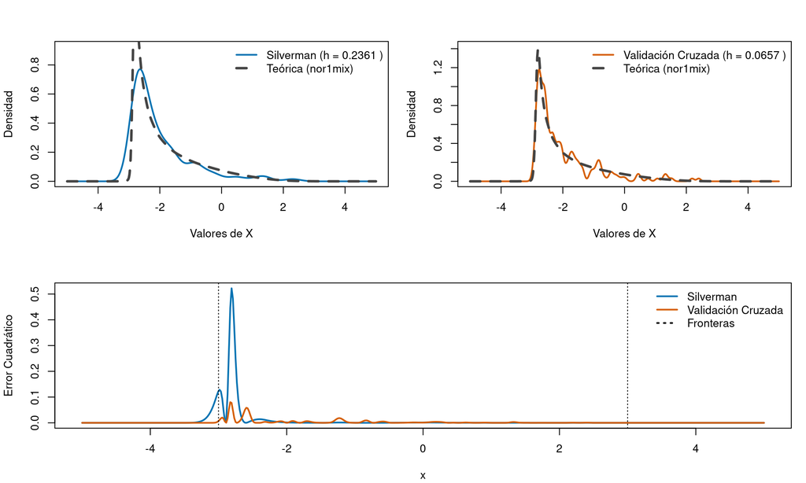

```r
resultados_Y32 <- analizar_y_graficar_mw(n = 2000,
                                         phi = 0,
                                         mw_obj = mw_list[[3]],
                                         lim_inf = -5,
                                         lim_sup = 5,
                                         lineas_diag = c(-3, 3),
                                         titulo_base = "Y32")
```

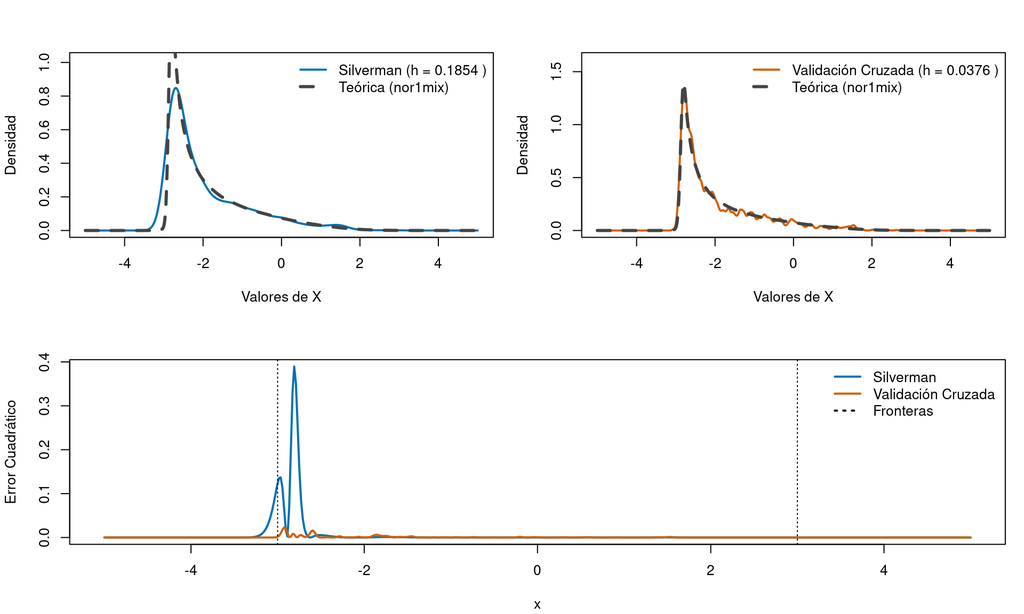

```r
resultados_Y33 <- analizar_y_graficar_mw(n = 200,
                                         phi = 0.9,
                                         mw_obj = mw_list[[3]],
                                         lim_inf = -5,
                                         lim_sup = 5,
                                         lineas_diag = c(-3, 3),
                                         titulo_base = "Y33")
```

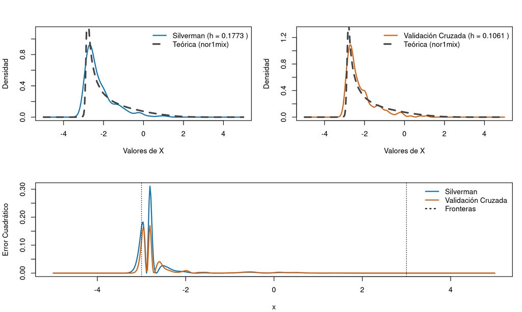

```r
resultados_Y34 <- analizar_y_graficar_mw(n = 2000,
                                         phi = 0.9,
                                         mw_obj = mw_list[[3]],
                                         lim_inf = -5,
                                         lim_sup = 5,
                                         lineas_diag = c(-3, 3),
                                         titulo_base = "Y34")
```

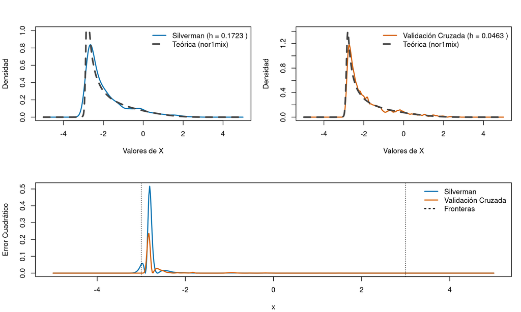

```r
resultados_Y41 <- analizar_y_graficar_mw(n = 200,
                                         phi = 0,
                                         mw_obj = mw_list[[4]],
                                         lim_inf = -5,
                                         lim_sup = 5,
                                         lineas_diag = c(-3, 3),
                                         titulo_base = "Y41")
```

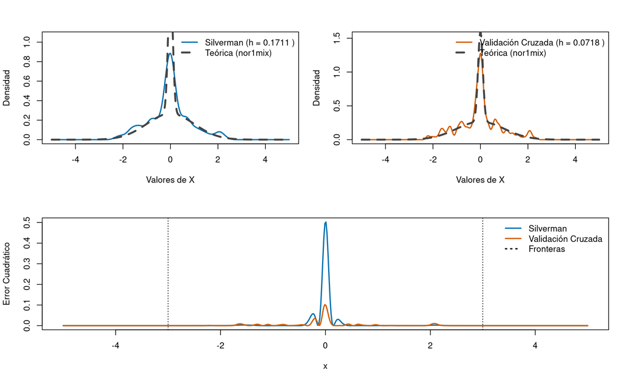

```r
resultados_Y42 <- analizar_y_graficar_mw(n = 2000,
                                         phi = 0,
                                         mw_obj = mw_list[[4]],
                                         lim_inf = -5,
                                         lim_sup = 5,
                                         lineas_diag = c(-3, 3),
                                         titulo_base = "Y42")
```

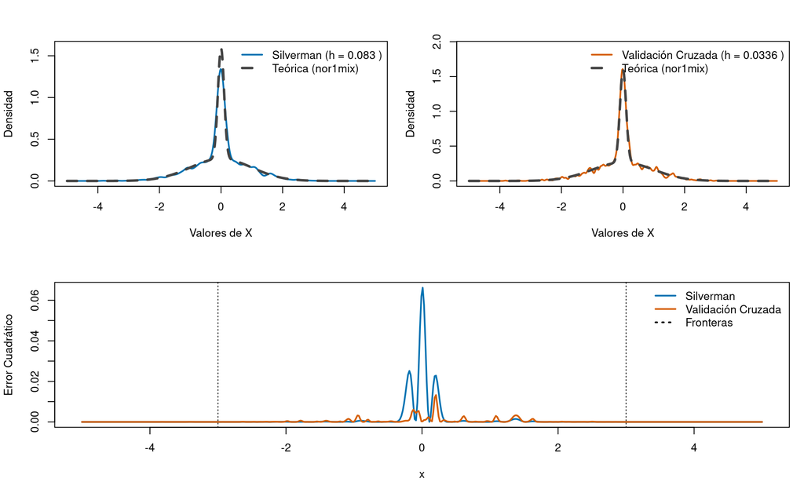

```r
resultados_Y43 <- analizar_y_graficar_mw(n = 200,
                                         phi = 0.9,
                                         mw_obj = mw_list[[4]],
                                         lim_inf = -5,
                                         lim_sup = 5,
                                         lineas_diag = c(-3, 3),
                                         titulo_base = "Y43")
```

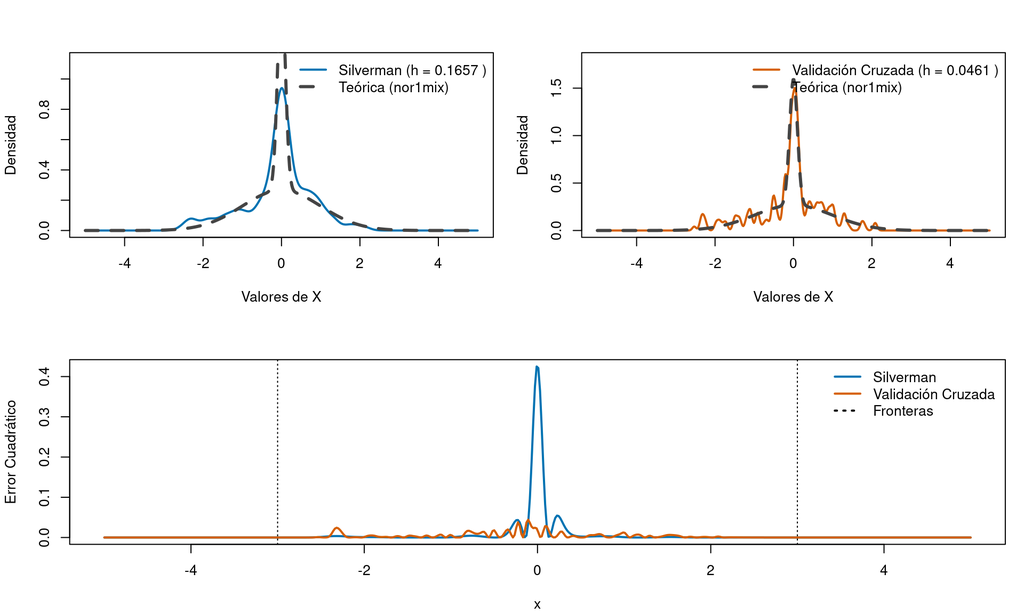

```r
resultados_Y44 <- analizar_y_graficar_mw(n = 2000,
                                         phi = 0.9,
                                         mw_obj = mw_list[[4]],
                                         lim_inf = -5,
                                         lim_sup = 5,
                                         lineas_diag = c(-3, 3),
                                         titulo_base = "Y44")
```

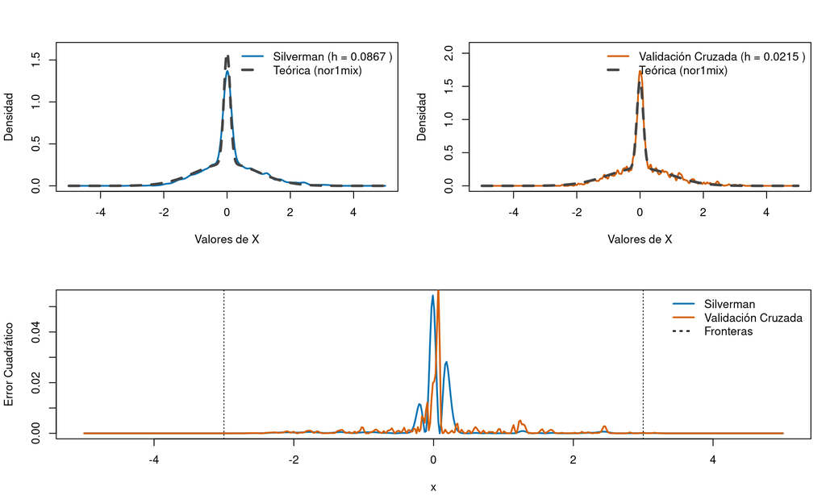

```r
resultados_Y51 <- analizar_y_graficar_mw(n = 200,
                                         phi = 0,
                                         mw_obj = mw_list[[5]],
                                         lim_inf = -5,
                                         lim_sup = 5,
                                         lineas_diag = c(-3, 3),
                                         titulo_base = "Y51")
```

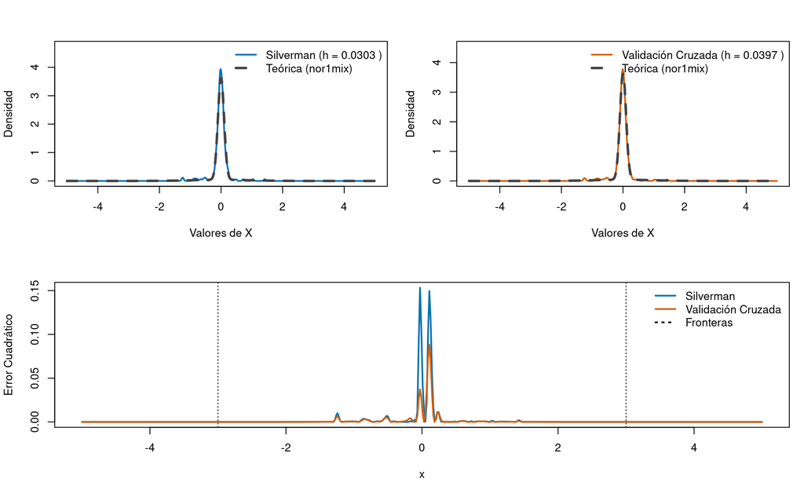

```r
resultados_Y52 <- analizar_y_graficar_mw(n = 2000,
                                         phi = 0,
                                         mw_obj = mw_list[[5]],
                                         lim_inf = -5,
                                         lim_sup = 5,
                                         lineas_diag = c(-3, 3),
                                         titulo_base = "Y52")
```

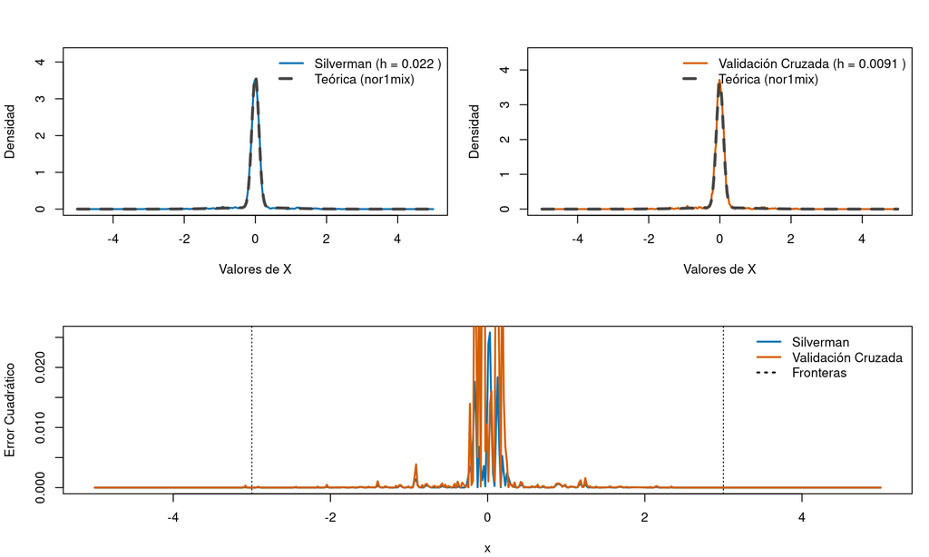

```r
resultados_Y53 <- analizar_y_graficar_mw(n = 200,
                                         phi = 0.9,
                                         mw_obj = mw_list[[5]],
                                         lim_inf = -5,
                                         lim_sup = 5,
                                         lineas_diag = c(-3, 3),
                                         titulo_base = "Y53")
```

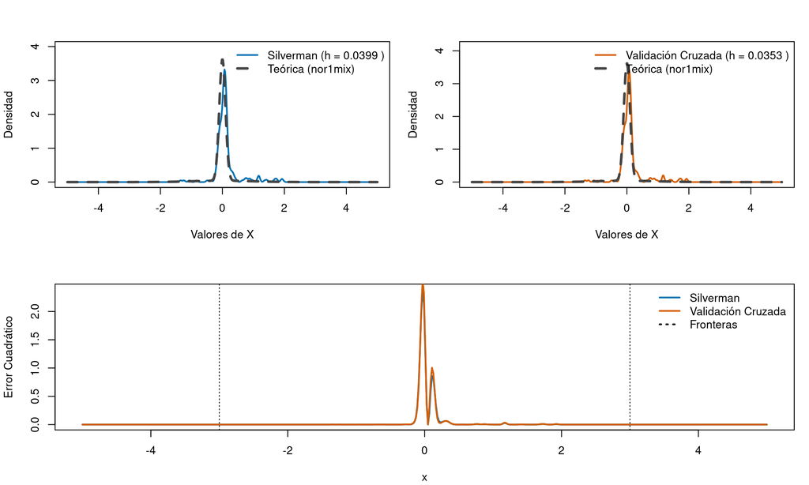

```r
resultados_Y54 <- analizar_y_graficar_mw(n = 2000,
                                         phi = 0.9,
                                         mw_obj = mw_list[[5]],
                                         lim_inf = -5,
                                         lim_sup = 5,
                                         lineas_diag = c(-3, 3),
                                         titulo_base = "Y54")
```

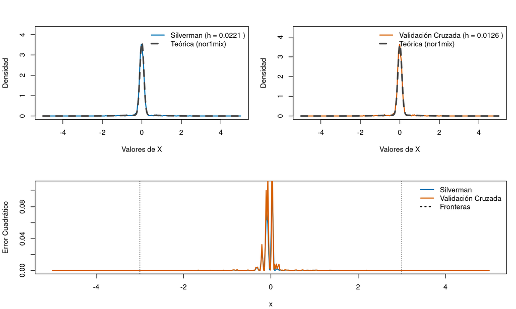

```r
resultados_Y61 <- analizar_y_graficar_mw(n = 200,
                                         phi = 0,
                                         mw_obj = mw_list[[6]],
                                         lim_inf = -5,
                                         lim_sup = 5,
                                         lineas_diag = c(-3, 3),
                                         titulo_base = "Y61")
```

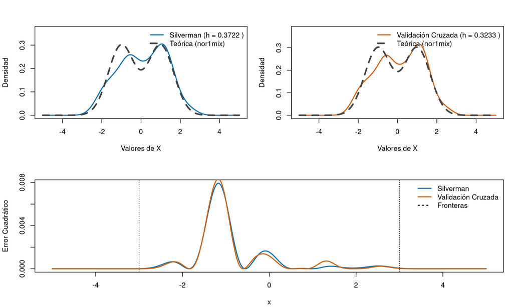

```r
resultados_Y62 <- analizar_y_graficar_mw(n = 2000,
                                         phi = 0,
                                         mw_obj = mw_list[[6]],
                                         lim_inf = -5,
                                         lim_sup = 5,
                                         lineas_diag = c(-3, 3),
                                         titulo_base = "Y62")
```

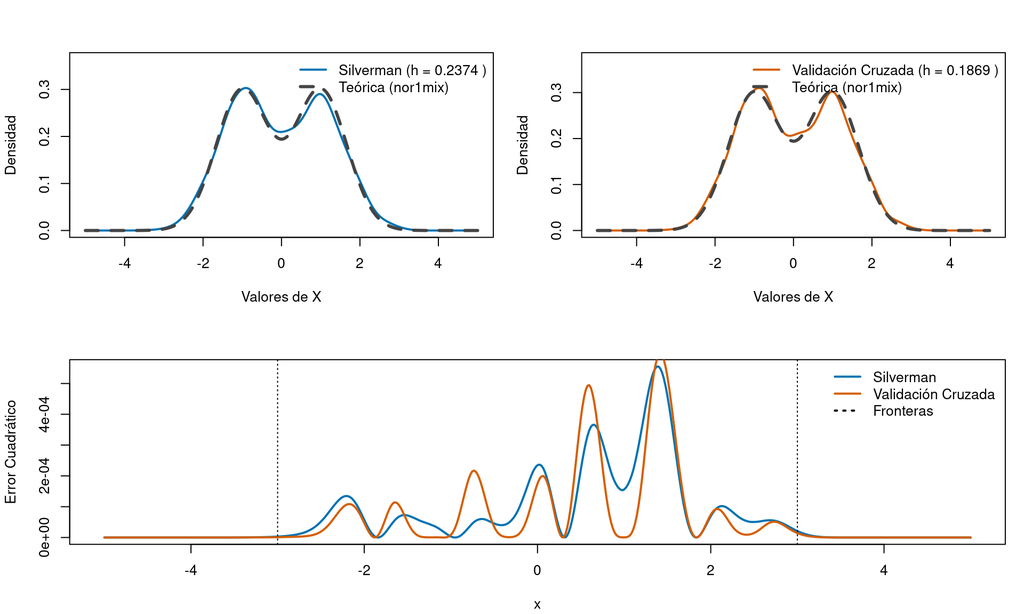

```r
resultados_Y63 <- analizar_y_graficar_mw(n = 200,
                                         phi = 0.9,
                                         mw_obj = mw_list[[6]],
                                         lim_inf = -5,
                                         lim_sup = 5,
                                         lineas_diag = c(-3, 3),
                                         titulo_base = "Y63")
```

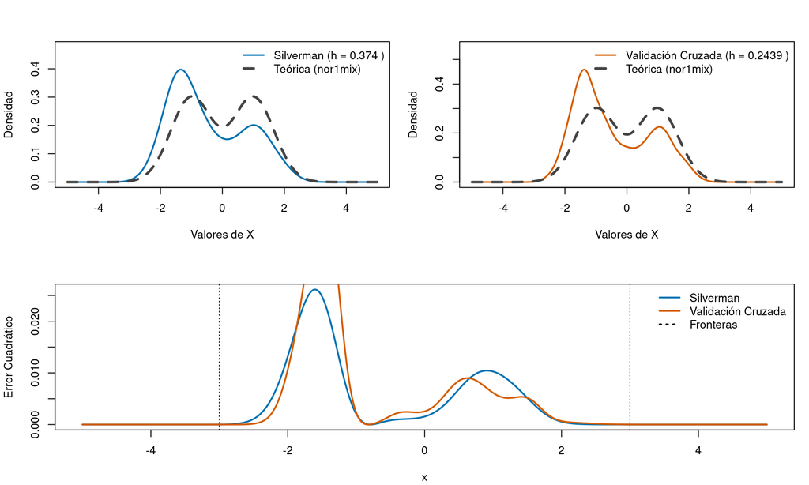

```r
resultados_Y64 <- analizar_y_graficar_mw(n = 2000,
                                         phi = 0.9,
                                         mw_obj = mw_list[[6]],
                                         lim_inf = -5,
                                         lim_sup = 5,
                                         lineas_diag = c(-3, 3),
                                         titulo_base = "Y64")
```

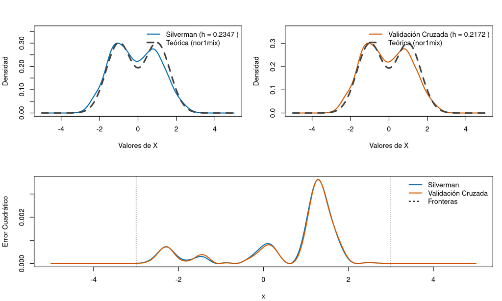

```r
resultados_Y71 <- analizar_y_graficar_mw(n = 200,
                                         phi = 0,
                                         mw_obj = mw_list[[7]],
                                         lim_inf = -5,
                                         lim_sup = 5,
                                         lineas_diag = c(-3, 3),
                                         titulo_base = "Y71")
```

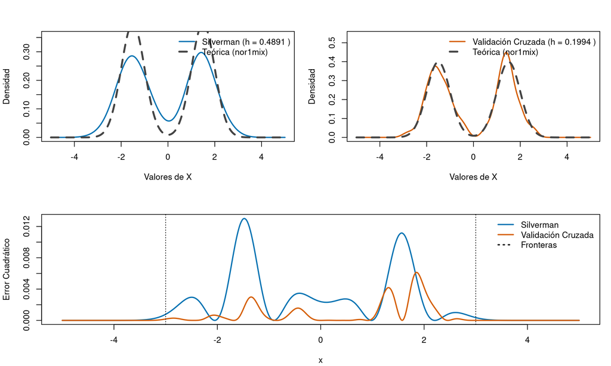

```r
resultados_Y72 <- analizar_y_graficar_mw(n = 2000,
                                         phi = 0,
                                         mw_obj = mw_list[[7]],
                                         lim_inf = -5,
                                         lim_sup = 5,
                                         lineas_diag = c(-3, 3),
                                         titulo_base = "Y72")
```

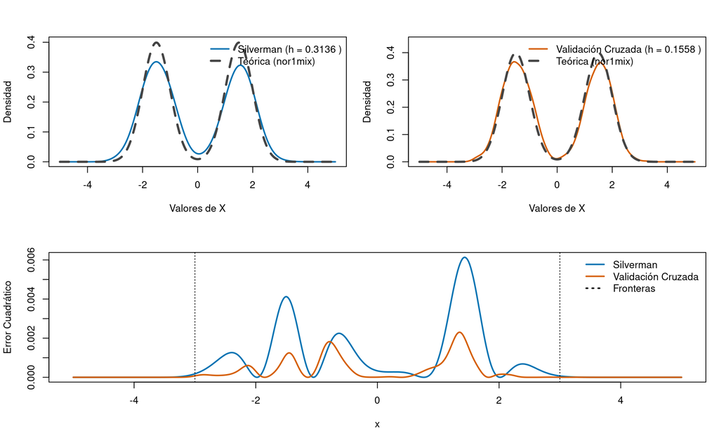

```r
resultados_Y73 <- analizar_y_graficar_mw(n = 200,
                                         phi = 0.9,
                                         mw_obj = mw_list[[7]],
                                         lim_inf = -5,
                                         lim_sup = 5,
                                         lineas_diag = c(-3, 3),
                                         titulo_base = "Y73")
```

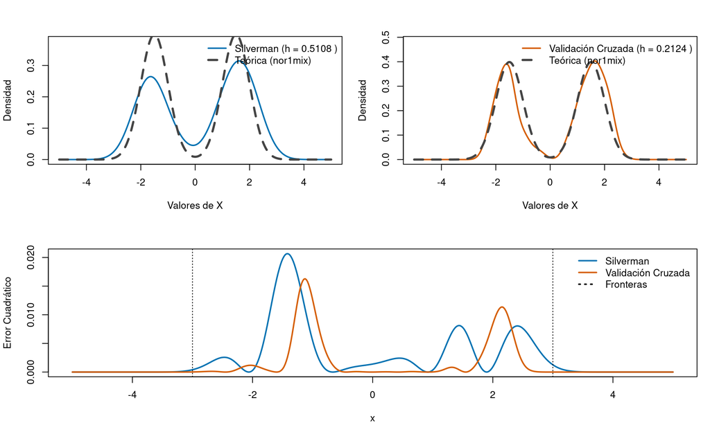

```r
resultados_Y74 <- analizar_y_graficar_mw(n = 2000,
                                         phi = 0.9,
                                         mw_obj = mw_list[[7]],
                                         lim_inf = -5,
                                         lim_sup = 5,
                                         lineas_diag = c(-3, 3),
                                         titulo_base = "Y74")
```

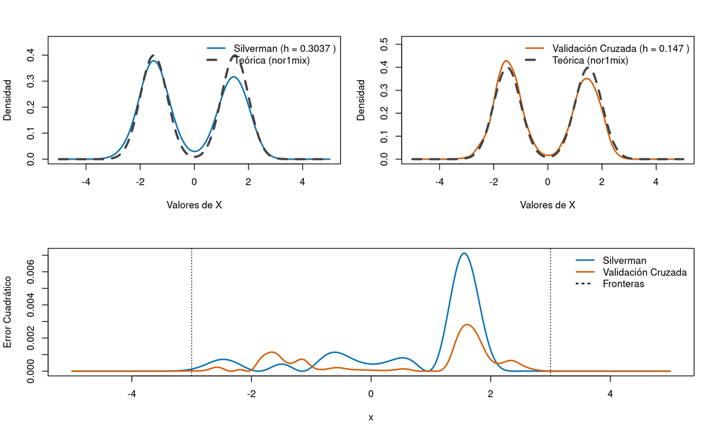

```r
resultados_Y81 <- analizar_y_graficar_mw(n = 200,
                                         phi = 0,
                                         mw_obj = mw_list[[8]],
                                         lim_inf = -5,
                                         lim_sup = 5,
                                         lineas_diag = c(-3, 3),
                                         titulo_base = "Y81")
```

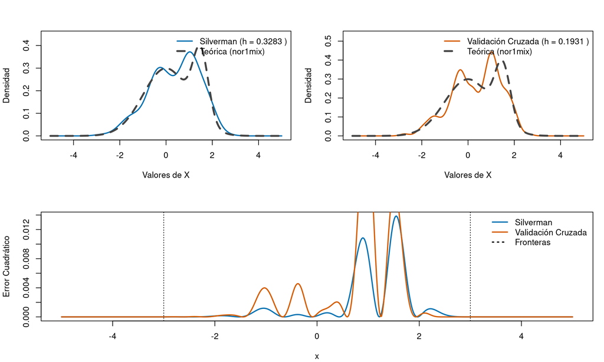